# Logistic Regression - Bank_Personal_Loan

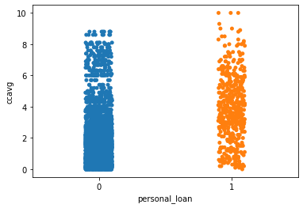

```python
ax = sns.stripplot(x="personal_loan", y="ccavg", data=bdata)
```

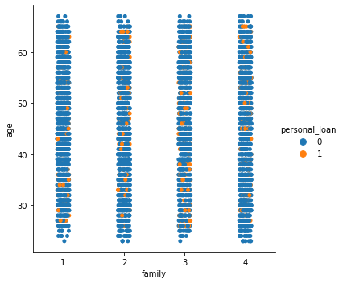

```python
g = sns.catplot(x="family", y="age", hue="personal_loan", data=bdata)
```

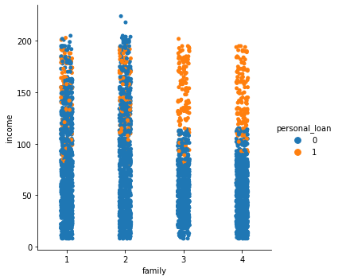

```python
g = sns.catplot(x="family", y="income", hue="personal_loan", data=bdata)
```

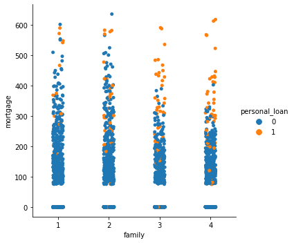

```python
g = sns.catplot(x="family", y="mortgage", hue="personal_loan", data=bdata)
```

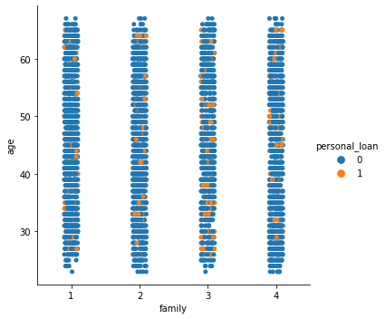

```python
g = sns.catplot(x="family", y="age", hue="personal_loan", data=bdata)
```

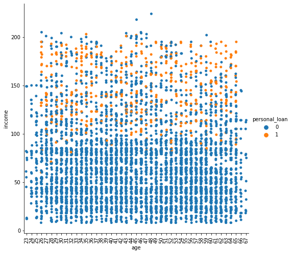

```python
sns.catplot(x="age", y="income", hue="personal_loan", data=bdata,height=7, aspect=1)
plt.xticks(rotation=90)
plt.show()
```

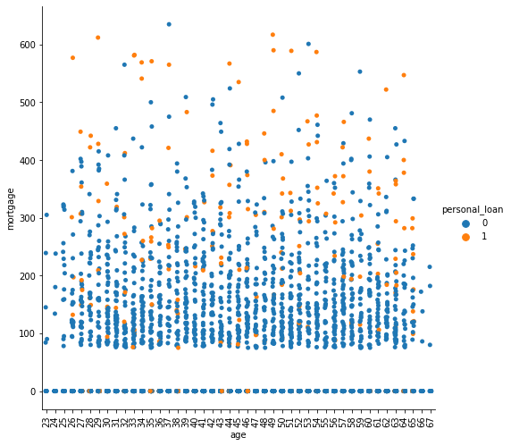

```python
sns.catplot(x="age", y="mortgage", hue="personal_loan", data=bdata,height=7, aspect=1)
plt.xticks(rotation=90)
plt.show()
```

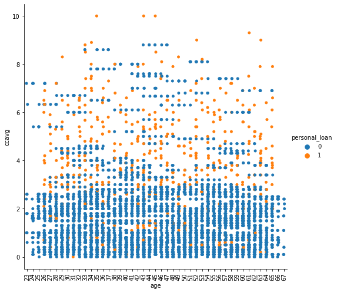

```python
sns.catplot(x="age", y="ccavg", hue="personal_loan", data=bdata,height=7, aspect=1)
plt.xticks(rotation=90)
plt.show()
```

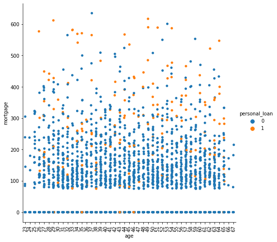

```python
sns.catplot(x="age", y="mortgage", hue="personal_loan", data=bdata,height=7, aspect=1)
plt.xticks(rotation=90)
plt.show()
```

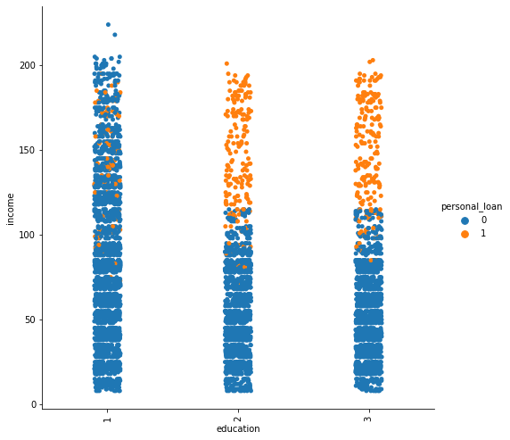

```python
sns.catplot(x="education", y="income", hue="personal_loan", data=bdata,height=7, aspect=1)
plt.xticks(rotation=90)
plt.show()
```

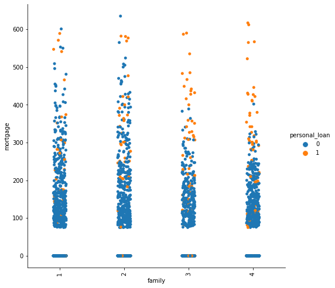

```python
sns.catplot(x="family", y="mortgage", hue="personal_loan", data=bdata,height=7, aspect=1)
plt.xticks(rotation=90)
plt.show()
```

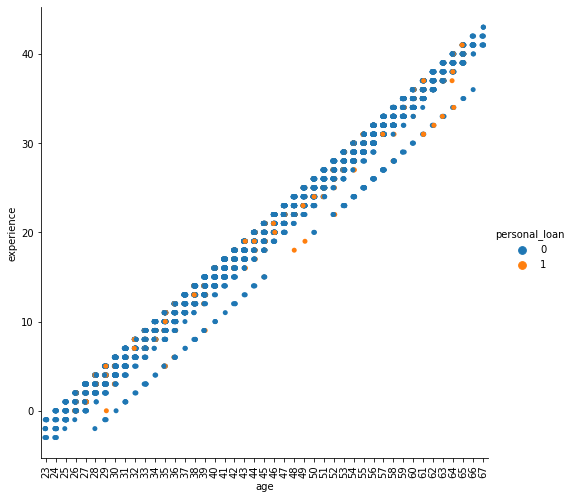

```python
sns.catplot(x="age", y="experience", hue="personal_loan", data=bdata,height=7, aspect=1)
plt.xticks(rotation=90)
plt.show()
```

**Insights:**

- People with higher income have taken personal loans
- People with larger mortgage amounts have taken personal loans
- People with higher credit card spending have taken personal loans
- People with higher education and higher income have taken personal loans
- People with larger family and higher income have taken personal loans

```python
pd.crosstab(bdata['age'],bdata['personal_loan'],normalize='index')
```

| personal_loan age | 0 | 1 |
| --- | --- | --- |
| 23 | 1.000000 | 0.000000 |
| 24 | 1.000000 | 0.000000 |
| 25 | 1.000000 | 0.000000 |
| 26 | 0.833333 | 0.166667 |
| 27 | 0.868132 | 0.131868 |
| 28 | 0.912621 | 0.087379 |
| 29 | 0.878049 | 0.121951 |
| 30 | 0.875000 | 0.125000 |
| 31 | 0.944000 | 0.056000 |
| 32 | 0.900000 | 0.100000 |
| 33 | 0.875000 | 0.125000 |
| 34 | 0.865672 | 0.134328 |
| 35 | 0.894040 | 0.105960 |
| 36 | 0.850467 | 0.149533 |
| 37 | 0.924528 | 0.075472 |
| 38 | 0.895652 | 0.104348 |
| 39 | 0.954887 | 0.045113 |
| 40 | 0.936000 | 0.064000 |
| 41 | 0.941176 | 0.058824 |
| 42 | 0.888889 | 0.111111 |
| 43 | 0.899329 | 0.100671 |
| 44 | 0.884298 | 0.115702 |
| 45 | 0.897638 | 0.102362 |
| 46 | 0.897638 | 0.102362 |
| 47 | 0.911504 | 0.088496 |
| 48 | 0.898305 | 0.101695 |
| 49 | 0.913043 | 0.086957 |
| 50 | 0.905797 | 0.094203 |
| 51 | 0.922481 | 0.077519 |
| 52 | 0.896552 | 0.103448 |
| 53 | 0.901786 | 0.098214 |
| 54 | 0.895105 | 0.104895 |
| 55 | 0.928000 | 0.072000 |
| 56 | 0.896296 | 0.103704 |
| 57 | 0.909091 | 0.090909 |
| 58 | 0.930070 | 0.069930 |
| 59 | 0.931818 | 0.068182 |
| 60 | 0.921260 | 0.078740 |
| 61 | 0.901639 | 0.098361 |
| 62 | 0.926829 | 0.073171 |
| 63 | 0.851852 | 0.148148 |
| 64 | 0.897436 | 0.102564 |
| 65 | 0.825000 | 0.175000 |
| 66 | 1.000000 | 0.000000 |
| 67 | 1.000000 | 0.000000 |

```python
pd.crosstab(bdata['experience'],bdata['personal_loan'],normalize='index')
```

| personal_loan experience | 0 | 1 |
| --- | --- | --- |
| -3 | 1.000000 | 0.000000 |
| -2 | 1.000000 | 0.000000 |
| -1 | 1.000000 | 0.000000 |
| 0 | 0.893939 | 0.106061 |
| 1 | 0.891892 | 0.108108 |
| 2 | 0.894118 | 0.105882 |
| 3 | 0.868217 | 0.131783 |
| 4 | 0.920354 | 0.079646 |
| 5 | 0.904110 | 0.095890 |
| 6 | 0.899160 | 0.100840 |
| 7 | 0.900826 | 0.099174 |
| 8 | 0.848739 | 0.151261 |
| 9 | 0.863946 | 0.136054 |
| 10 | 0.940678 | 0.059322 |
| 11 | 0.887931 | 0.112069 |
| 12 | 0.843137 | 0.156863 |
| 13 | 0.905983 | 0.094017 |
| 14 | 0.952756 | 0.047244 |
| 15 | 0.957983 | 0.042017 |
| 16 | 0.897638 | 0.102362 |
| 17 | 0.912000 | 0.088000 |
| 18 | 0.912409 | 0.087591 |
| 19 | 0.896296 | 0.103704 |
| 20 | 0.885135 | 0.114865 |
| 21 | 0.902655 | 0.097345 |
| 22 | 0.895161 | 0.104839 |
| 23 | 0.909722 | 0.090278 |
| 24 | 0.938931 | 0.061069 |
| 25 | 0.901408 | 0.098592 |
| 26 | 0.895522 | 0.104478 |
| 27 | 0.920000 | 0.080000 |
| 28 | 0.920290 | 0.079710 |
| 29 | 0.903226 | 0.096774 |
| 30 | 0.896825 | 0.103175 |
| 31 | 0.884615 | 0.115385 |
| 32 | 0.909091 | 0.090909 |
| 33 | 0.940171 | 0.059829 |
| 34 | 0.920000 | 0.080000 |
| 35 | 0.909091 | 0.090909 |
| 36 | 0.894737 | 0.105263 |
| 37 | 0.887931 | 0.112069 |
| 38 | 0.909091 | 0.090909 |
| 39 | 0.882353 | 0.117647 |
| 40 | 0.929825 | 0.070175 |
| 41 | 0.837209 | 0.162791 |
| 42 | 1.000000 | 0.000000 |
| 43 | 1.000000 | 0.000000 |

```python
pd.crosstab(bdata['income'],bdata['personal_loan'],normalize='index')
```

| personal_loan income | 0 | 1 |
| --- | --- | --- |
| 8 | 1.0 | 0.0 |
| 9 | 1.0 | 0.0 |
| 10 | 1.0 | 0.0 |
| 11 | 1.0 | 0.0 |
| 12 | 1.0 | 0.0 |
| ... | ... | ... |
| 203 | 0.5 | 0.5 |
| 204 | 1.0 | 0.0 |
| 205 | 1.0 | 0.0 |
| 218 | 1.0 | 0.0 |
| 224 | 1.0 | 0.0 |

162 rows × 2 columns

```python
pd.crosstab(bdata['zip_code'],bdata['personal_loan'],normalize='index')
```

| personal_loan zip_code | 0 | 1 |
| --- | --- | --- |
| 9307 | 1.0 | 0.0 |
| 90005 | 1.0 | 0.0 |
| 90007 | 1.0 | 0.0 |
| 90009 | 1.0 | 0.0 |
| 90011 | 1.0 | 0.0 |
| ... | ... | ... |
| 96091 | 1.0 | 0.0 |
| 96094 | 1.0 | 0.0 |
| 96145 | 1.0 | 0.0 |
| 96150 | 1.0 | 0.0 |
| 96651 | 1.0 | 0.0 |

467 rows × 2 columns

```python
#Drawing relationships in data
bdata.groupby(['personal_loan','family','education'])['online'].value_counts()
```

```
personal_loan  family  education  online
0              1       1          1         395
                                  0         274
                       2          1         175
                                  0         111
                       3          1         245
                                  0         165
               2       1          1         389
                                  0         264
                       2          1         115
                                  0         100
                       3          1         180
                                  0         142
               3       1          1         187
                                  0         122
```

[output cut: 35 more lines]

```python
#Drawing relationships in data
bdata.groupby(['personal_loan','family','education'])['creditcard'].value_counts()
```

```
personal_loan  family  education  creditcard
0              1       1          0             487
                                  1             182
                       2          0             200
                                  1              86
                       3          0             298
                                  1             112
               2       1          0             452
                                  1             201
                       2          0             139
                                  1              76
                       3          0             224
                                  1              98
               3       1          0             218
                                  1              91
```

[output cut: 35 more lines]

```python
#Drawing relationships in data
bdata.groupby(['personal_loan','family','education'])['cd_account'].value_counts()
```

```
personal_loan  family  education  cd_account
0              1       1          0             645
                                  1              24
                       2          0             275
                                  1              11
                       3          0             398
                                  1              12
               2       1          0             624
                                  1              29
                       2          0             209
                                  1               6
                       3          0             311
                                  1              11
               3       1          0             292
                                  1              17
```

[output cut: 34 more lines]

```python
bdata.groupby(['personal_loan','family','education'])['securities_account'].value_counts()
```

```
personal_loan  family  education  securities_account
0              1       1          0                     613
                                  1                      56
                       2          0                     253
                                  1                      33
                       3          0                     378
                                  1                      32
               2       1          0                     583
                                  1                      70
                       2          0                     191
                                  1                      24
                       3          0                     291
                                  1                      31
               3       1          0                     272
                                  1                      37
```

[output cut: 34 more lines]

**Task 2.6 - Get data model ready**

- Data Preparation
- Check hidden missing or incorrect values

As we checked missing values earlier but we did not find any values missing. However we found negative values in experience column. We have few options as explained below.

### Experience column has negative values like -1,-2,-3

```python
#Experience column data has problem where numbers like -1, -2, -3 exist
#options -

#1 - change -ve values to +ve thinking -ve sign was typo (using this option
#based on suggestion by Great Learning response to the question posed in this project discussion forum)

#2 - replace the negative numbers by mean experience

#3 - Drop the column experience as it does not seem relevant

# switch the -ve values in experience column to positive values as these values seem typos and
#the values that are negative seems that similar positive values do exist in the dataset
#(using this option #based on suggestion by Great Learning response to the question posed in this project discussion forum)
bdata['experience'] = bdata['experience'].abs()
```

```python
bdata.head(10)
```

|  | age | experience | income | zip_code | family | ccavg | education | mortgage | personal_loan | securities_account | cd_account | online | creditcard |
| --- | --- | --- | --- | --- | --- | --- | --- | --- | --- | --- | --- | --- | --- |
| 0 | 25 | 1 | 49 | 91107 | 4 | 1.6 | 1 | 0 | 0 | 1 | 0 | 0 | 0 |
| 1 | 45 | 19 | 34 | 90089 | 3 | 1.5 | 1 | 0 | 0 | 1 | 0 | 0 | 0 |
| 2 | 39 | 15 | 11 | 94720 | 1 | 1.0 | 1 | 0 | 0 | 0 | 0 | 0 | 0 |
| 3 | 35 | 9 | 100 | 94112 | 1 | 2.7 | 2 | 0 | 0 | 0 | 0 | 0 | 0 |
| 4 | 35 | 8 | 45 | 91330 | 4 | 1.0 | 2 | 0 | 0 | 0 | 0 | 0 | 1 |
| 5 | 37 | 13 | 29 | 92121 | 4 | 0.4 | 2 | 155 | 0 | 0 | 0 | 1 | 0 |
| 6 | 53 | 27 | 72 | 91711 | 2 | 1.5 | 2 | 0 | 0 | 0 | 0 | 1 | 0 |
| 7 | 50 | 24 | 22 | 93943 | 1 | 0.3 | 3 | 0 | 0 | 0 | 0 | 0 | 1 |
| 8 | 35 | 10 | 81 | 90089 | 3 | 0.6 | 2 | 104 | 0 | 0 | 0 | 1 | 0 |
| 9 | 34 | 9 | 180 | 93023 | 1 | 8.9 | 3 | 0 | 1 | 0 | 0 | 0 | 0 |

- Define X and Y variables

```python
#Define X and Y variables
X = bdata.drop('personal_loan',axis=1)

Y = bdata['personal_loan']
```

## Task 3 - Split the data into training and test set in the ratio of 70:30 respectively

We will use 70% of data for training and 30% for testing.

```python
##Split into training and test set
from sklearn.model_selection import train_test_split

X_train, X_test, y_train, y_test = train_test_split(X, Y, test_size=0.30,random_state=7)

X_train.head()
```

|  | age | experience | income | zip_code | family | ccavg | education | mortgage | securities_account | cd_account | online | creditcard |
| --- | --- | --- | --- | --- | --- | --- | --- | --- | --- | --- | --- | --- |
| 717 | 59 | 34 | 94 | 93940 | 3 | 0.5 | 1 | 0 | 0 | 0 | 0 | 1 |
| 2496 | 63 | 37 | 32 | 93117 | 3 | 0.7 | 2 | 141 | 0 | 0 | 0 | 0 |
| 2469 | 43 | 18 | 89 | 92780 | 1 | 0.1 | 2 | 307 | 0 | 0 | 0 | 1 |
| 1375 | 50 | 26 | 179 | 92612 | 1 | 2.9 | 3 | 0 | 0 | 0 | 0 | 1 |
| 2742 | 39 | 14 | 89 | 95762 | 2 | 0.4 | 1 | 0 | 0 | 0 | 1 | 0 |

Lets check split of data

```python
print("{0:0.2f}% data is in training set".format((len(X_train)/len(bdata.index)) * 100))
print("{0:0.2f}% data is in test set".format((len(X_test)/len(bdata.index)) * 100))
```

```
70.00% data is in training set
30.00% data is in test set
```

Now lets check Personal Loan True/False ratio in split data

```python
print("Original Personal Loan True Values    : {0} ({1:0.2f}%)".format(len(bdata.loc[bdata['personal_loan'] == 1]), (len(bdata.loc[bdata['personal_loan'] == 1])/len(bdata.index)) * 100))
print("Original Personal Loan False Values   : {0} ({1:0.2f}%)".format(len(bdata.loc[bdata['personal_loan'] == 0]), (len(bdata.loc[bdata['personal_loan'] == 0])/len(bdata.index)) * 100))
print("")
print("Training Personal Loan True Values    : {0} ({1:0.2f}%)".format(len(y_train[y_train[:] == 1]), (len(y_train[y_train[:] == 1])/len(y_train)) * 100))
print("Training Personal Loan False Values   : {0} ({1:0.2f}%)".format(len(y_train[y_train[:] == 0]), (len(y_train[y_train[:] == 0])/len(y_train)) * 100))
print("")
print("Test Personal Loan True Values        : {0} ({1:0.2f}%)".format(len(y_test[y_test[:] == 1]), (len(y_test[y_test[:] == 1])/len(y_test)) * 100))
print("Test Personal Loan False Values       : {0} ({1:0.2f}%)".format(len(y_test[y_test[:] == 0]), (len(y_test[y_test[:] == 0])/len(y_test)) * 100))
print("")
```

```
Original Personal Loan True Values    : 480 (9.60%)
Original Personal Loan False Values   : 4520 (90.40%)

Training Personal Loan True Values    : 342 (9.77%)
Training Personal Loan False Values   : 3158 (90.23%)

Test Personal Loan True Values        : 138 (9.20%)
Test Personal Loan False Values       : 1362 (90.80%)
```

## Task 4 - Use Logistic Regression model to predict whether the customer will take personal loan or not. Print all the metrics related for evaluating the model performance

```python
from sklearn.metrics import confusion_matrix, recall_score, precision_score, f1_score, roc_auc_score,accuracy_score
from sklearn.linear_model import LogisticRegression

#logreg = LogisticRegression(random_state=7, class_weight='balanced')
logreg = LogisticRegression(random_state=7)
logreg.fit(X_train, y_train)                    # fit the model on train data
```

```
LogisticRegression(C=1.0, class_weight=None, dual=False, fit_intercept=True,
                   intercept_scaling=1, l1_ratio=None, max_iter=100,
                   multi_class='auto', n_jobs=None, penalty='l2',
                   random_state=7, solver='lbfgs', tol=0.0001, verbose=0,
                   warm_start=False)
```

```python
#predict on test
y_predict = logreg.predict(X_test)
```

```python
coef_df = pd.DataFrame(logreg.coef_)
coef_df['intercept'] = logreg.intercept_
print(coef_df)
```

```
          0         1         2         3         4        5         6  \
0  0.000061  0.000044  0.034562 -0.000063  0.000165  0.00104  0.000254

          7         8         9        10        11     intercept
0  0.000902  0.000024  0.000132  0.000005  0.000002 -8.044715e-07
```

```python
# Observe the predicted and observed classes in a dataframe.

z = X_test.copy()
z['Observed Loan Status'] = y_test
z['Predicted Loan Status'] = y_predict
z.head(10)
```

|  | age | experience | income | zip_code | family | ccavg | education | mortgage | securities_account | cd_account | online | creditcard | Observed Loan Status | Predicted Loan Status |
| --- | --- | --- | --- | --- | --- | --- | --- | --- | --- | --- | --- | --- | --- | --- |
| 3406 | 42 | 12 | 34 | 92177 | 3 | 2.0 | 3 | 0 | 0 | 0 | 0 | 1 | 0 | 0 |
| 757 | 52 | 28 | 81 | 91745 | 3 | 1.8 | 2 | 0 | 1 | 0 | 0 | 0 | 0 | 0 |
| 3624 | 58 | 28 | 70 | 92028 | 1 | 1.4 | 3 | 0 | 0 | 0 | 0 | 0 | 0 | 0 |
| 4544 | 28 | 4 | 80 | 95819 | 3 | 2.5 | 1 | 0 | 0 | 0 | 1 | 0 | 0 | 0 |
| 3235 | 60 | 35 | 39 | 91711 | 2 | 1.6 | 3 | 0 | 0 | 0 | 1 | 0 | 0 | 0 |
| 1868 | 25 | 1 | 118 | 92833 | 1 | 5.4 | 1 | 0 | 0 | 0 | 1 | 1 | 0 | 0 |
| 2916 | 46 | 20 | 40 | 92037 | 1 | 1.2 | 2 | 0 | 0 | 0 | 1 | 0 | 0 | 0 |
| 3335 | 35 | 10 | 118 | 92069 | 2 | 7.8 | 1 | 358 | 0 | 0 | 0 | 0 | 0 | 0 |
| 3527 | 35 | 10 | 24 | 95054 | 4 | 1.1 | 3 | 0 | 0 | 0 | 0 | 0 | 0 | 0 |
| 2827 | 37 | 11 | 84 | 90266 | 4 | 2.2 | 2 | 0 | 0 | 0 | 1 | 1 | 0 | 0 |

```python
## function to get confusion matrix in a proper format
def draw_cm( actual, predicted ):
    cm = confusion_matrix( actual, predicted)
    sns.heatmap(cm, annot=True,  fmt='.2f', xticklabels = [0,1] , yticklabels = [0,1] )
    plt.ylabel('Observed')
    plt.xlabel('Predicted')
    plt.show()
```

```
===============================================================
METRICS RELATED TO MODEL PERFORMANCE
===============================================================
Trainig accuracy 0.9042857142857142

Testing accuracy 0.9153333333333333

Confusion Matrix
```

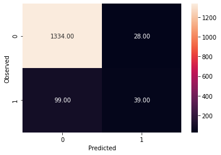

```
None

Recall: 0.2826086956521739

Precision: 0.582089552238806

F1 Score: 0.38048780487804873

Roc Auc Score: 0.6310253463576582
```

```python
print("===============================================================")
print("METRICS RELATED TO MODEL PERFORMANCE")
print("===============================================================")
print("Trainig accuracy",logreg.score(X_train,y_train))
print()
print("Testing accuracy",logreg.score(X_test, y_test))
print()
print('Confusion Matrix')
print(draw_cm(y_test,y_predict))
print()
print("Recall:",recall_score(y_test,y_predict))
print()
print("Precision:",precision_score(y_test,y_predict))
print()
print("F1 Score:",f1_score(y_test,y_predict))
print()
print("Roc Auc Score:",roc_auc_score(y_test,y_predict))
```

## Task 5 - Check different parameters of Logistic Regression and give your reasoning whether the model performance is affected due to it or not?

```python
#Task 5

# Checking Parameters of logistic regression
logreg.get_params()

#If we dont specify the parameters in the model it takes default value
```

```
{'C': 1.0,
 'class_weight': None,
 'dual': False,
 'fit_intercept': True,
 'intercept_scaling': 1,
 'l1_ratio': None,
 'max_iter': 100,
 'multi_class': 'auto',
 'n_jobs': None,
 'penalty': 'l2',
 'random_state': 7,
 'solver': 'lbfgs',
 'tol': 0.0001,
 'verbose': 0,
 'warm_start': False}
```

```python
# Running a loop to check different values of 'solver'
# all solver can be used with l2, only 'liblinear' and 'saga' works with both 'l1' and 'l2'

train_score=[]
test_score=[]
solver = ['newton-cg','lbfgs','liblinear','sag','saga']
for i in solver:
    model = LogisticRegression(random_state=42,penalty='l2', C = 0.75,solver=i)  # changing values of solver
    model.fit(X_train, y_train)
    y_predict = model.predict(X_test)
    train_score.append(round(model.score(X_train, y_train),3))
    test_score.append(round(model.score(X_test, y_test),3))

print(solver)
print()
print(train_score)
print()
print(test_score)
```

```
['newton-cg', 'lbfgs', 'liblinear', 'sag', 'saga']

[0.949, 0.904, 0.905, 0.902, 0.902]

[0.955, 0.915, 0.918, 0.908, 0.908]
```

```python
train_score=[]
test_score=[]
solver = ['liblinear','saga']   # changing values of solver which works with 'l1'
for i in solver:
    model = LogisticRegression(random_state=42,penalty='l1', C = 0.75,solver=i)  #changed penalty to 'l1'
    model.fit(X_train, y_train)
    y_predict = model.predict(X_test)
    train_score.append(round(model.score(X_train, y_train),3))
    test_score.append(round(model.score(X_test, y_test),3))

print(solver)
print()
print(train_score)
print()
print(test_score)
```

```
['liblinear', 'saga']

[0.949, 0.902]

[0.955, 0.908]
```

**Insights:**

- `Highest accuracy is 'l1' with 'liblinear' and 'l2' with newton-cg. Any of these two can be used in final model.`

```python
#We will use the 'l1' with 'liblinear' model as final model

model = LogisticRegression(random_state=42,penalty='l1',solver='liblinear')

model.fit(X_train, y_train)

y_predict = model.predict(X_test)

print("Trainig accuracy",model.score(X_train,y_train))
print()
print("Testing accuracy",model.score(X_test, y_test))
```

```
Trainig accuracy 0.9497142857142857

Testing accuracy 0.9553333333333334
```

**Insights:**

- `Training and Testing accuracy increased from first model execution`

```python
# Running a loop to check different values of 'C'

train_score=[]
test_score=[]
C = [0.01,0.1,0.25,0.5,0.75,1]
for i in C:
    model = LogisticRegression(random_state=42,penalty='l1', solver='liblinear', C=i)  # changing values of C
    model.fit(X_train, y_train)
    y_predict = model.predict(X_test)
    train_score.append(round(model.score(X_train,y_train),3)) # appending training accuracy in a blank list for every run of the loop
    test_score.append(round(model.score(X_test, y_test),3))   # appending testing accuracy in a blank list for every run of the loop

print(C)
print()
print(train_score)
print()
print(test_score)
```

```
[0.01, 0.1, 0.25, 0.5, 0.75, 1]

[0.925, 0.947, 0.948, 0.948, 0.949, 0.95]

[0.939, 0.953, 0.953, 0.955, 0.955, 0.955]
```

**Insights:**

- `Training and Testing accuracy is highest with C=1`

```
===============================================================
METRICS RELATED TO MODEL PERFORMANCE
===============================================================
Trainig accuracy 0.9497142857142857

Testing accuracy 0.9553333333333334

Confusion Matrix
```

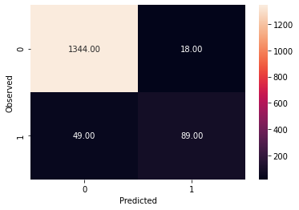

```
None

Recall: 0.644927536231884

Precision: 0.8317757009345794

F1 Score: 0.726530612244898

Roc Auc Score: 0.8158558386005235
```

```python
#Therefore final model is liblinear with l1 and C=1
model = LogisticRegression(random_state=42,penalty='l1', solver='liblinear',C=1)
model.fit(X_train, y_train)
y_predict = model.predict(X_test)
print("===============================================================")
print("METRICS RELATED TO MODEL PERFORMANCE")
print("===============================================================")
print("Trainig accuracy",model.score(X_train,y_train))
print()
print("Testing accuracy",model.score(X_test, y_test))
print()
print('Confusion Matrix')
print(draw_cm(y_test,y_predict))
print()
print("Recall:",recall_score(y_test,y_predict))
print()
print("Precision:",precision_score(y_test,y_predict))
print()
print("F1 Score:",f1_score(y_test,y_predict))
print()
print("Roc Auc Score:",roc_auc_score(y_test,y_predict))
```

**Insights:**

## Task 5 Conclusion:

**Task 5 Conclusion:** There is significant improvement in the model performance based on adjustement in model parameters.

**First execution with default parameters**

- Trainig accuracy 0.9042857142857142
- Testing accuracy 0.9153333333333333
- Recall: 0.2826086956521739
- Precision: 0.582089552238806
- F1 Score: 0.38048780487804873
- Roc Auc Score: 0.6310253463576582

**Final execution with improved parameters based on various adjustments**

- Trainig accuracy 0.9497142857142857
- Testing accuracy 0.9553333333333334
- Recall: 0.644927536231884
- Precision: 0.8317757009345794
- F1 Score: 0.726530612244898
- Roc Auc Score: 0.8158558386005235

## Task 6 - Give Business understanding of your model?

**Confusion matrix results description**

**True Positive (observed=1,predicted=1) 89 customers:**

Predicted that the customer did accept personal loan offered and based on last campaign data the customer did accept the personal loan offered. This group of customers are the correct target and bank will be able to take advantage of this model to target their campaign towards the right customer.

**False Positive (observed=0,predicted=1) 18 customers:**

Predicted that the customer did accept personal loan offered and based on last campaign data the customer did not accept the personal loan offered. This will be the additional expense for the marketing department where they will send the offer to these 18 customers who will not accept the loan offer.

**True Negative (observed=0,predicted=0):1344 customers**

Predicted that the customer did not accept personal loan offered and based on last campaign data the customer did not accept the personal loan offered. This correct prediction will enable the bank to save expenses incurred in marketing to the customers where there is no chance of acceptance.

**False Negative (observed=1,predicted=0) 49 customers:**

Predicted that the customer did not accept personal loan offered and based on last campaign data the customer did accept the personal loan offered. This prediction is resulting in not targeting the customers who were seen to be accepting the loan offered. This means the loss of potential revenue for the bank.

The bank wants to target the right customers by offering the loan to the people by creating a model developed by studying the customers who accepted the personal loan in last campaign i.e. **less number of False Positive**, if FP is high there is a chance that bank offers the personal loans to customers who will not accept the personal loan resulting in spending the money in marketing efforts that will have no potential returns. So in the final model we have to make sure there are least false positive predictions. Hence **Precision is the important metric**.

In case of false negative bank will lose few customers but that's okay because the bank is not incurring extra cost in this case and retaining that capital to be used for other purposes.

After achieving the desired accuracy we can deploy the model for practical use. The bank now can predict who will accept the personal loan and send the offers accordingly to maximize the acceptance by targeting the right customers and maximizing the cost benefit of the personal loan campaign. They can use the model for upcoming new customers or existing customers to find the group of customers that can be targeted for personal loan campaign.